# Lab-01

Shuyi Chen

2023-07-28

# Unix

```bash
# 1.Show the Unix command that you would use to create a directory to hold the files for this lab (including your R Markdown file) and show the Unix command to navigate to that directory.
curl https://www.stat.auckland.ac.nz/~su/769/medicaments.tar.gz | tar vxz
mkdir medicaments_lab
for year in {2000..2022}; do mv "medicaments-$year.csv" "medicaments_lab/"; done
# 2.Write a shell command that shows information about all the data files including the size in bytes for each of them.
cd medicaments_lab
```

```bash
ls -l *.csv

# 3.Write a shell command that shows the number of lines in the medicaments-2020.csv file.
wc -l medicaments-2020.csv

# 4.We are interested in records HS code (HSC) 3004901919. Write a shell command that extracts all records with HSC 3004901919 from all the files into a new file 3004901919.data. Then write a shell command that counts the number of lines in the newly created file.
grep -hr '3004901919' *.csv > 3004901919.data
wc -l 3004901919.data

# 5.Write a shell command that extracts the month column from the 3004901919.data file and prints the smallest value of that column. Repeat the same for the largest value. Do you see anything suspicious?
cut -d',' -f 1 3004901919.data | sort -n | tail -1
cut -d',' -f 1 3004901919.data | sort -n | head -1

# The data set includes CSVS from 2000 to 2022, but the maximum results are shown as 2016 values, which may be missing data values

# 6. Write a shell script which returns total counts (number of lines) for all HS codes (taking into account all files) in ascending count order and print the last five lines of the output.
grep -hr -oE '[0-9]{10}' ./*.csv | sort | uniq -c | sort -n | tail -5
```

```
## -rw-r----- 1 sche796 sche796 304448 Jul 25 15:45 medicaments-2000.csv
## -rw-r----- 1 sche796 sche796 305611 Jul 25 15:45 medicaments-2001.csv
## -rw-r----- 1 sche796 sche796 295694 Jul 25 15:45 medicaments-2002.csv
## -rw-r----- 1 sche796 sche796 304977 Jul 25 15:45 medicaments-2003.csv
## -rw-r----- 1 sche796 sche796 334718 Jul 25 15:45 medicaments-2004.csv
## -rw-r----- 1 sche796 sche796 341749 Jul 25 15:45 medicaments-2005.csv
## -rw-r----- 1 sche796 sche796 334584 Jul 25 15:45 medicaments-2006.csv
## -rw-r----- 1 sche796 sche796 330993 Jul 25 15:45 medicaments-2007.csv
## -rw-r----- 1 sche796 sche796 336221 Jul 25 15:45 medicaments-2008.csv
## -rw-r----- 1 sche796 sche796 333563 Jul 25 15:45 medicaments-2009.csv
## -rw-r----- 1 sche796 sche796 351277 Jul 25 15:45 medicaments-2010.csv
## -rw-r----- 1 sche796 sche796 364676 Jul 25 15:45 medicaments-2011.csv
## -rw-r----- 1 sche796 sche796 359288 Jul 25 15:45 medicaments-2012.csv
## -rw-r----- 1 sche796 sche796 363646 Jul 25 15:45 medicaments-2013.csv
## -rw-r----- 1 sche796 sche796 363945 Jul 25 15:45 medicaments-2014.csv
## -rw-r----- 1 sche796 sche796 369729 Jul 25 15:45 medicaments-2015.csv
## -rw-r----- 1 sche796 sche796 375071 Jul 25 15:45 medicaments-2016.csv
## -rw-r----- 1 sche796 sche796 390556 Jul 25 15:45 medicaments-2017.csv
## -rw-r----- 1 sche796 sche796 397085 Jul 25 15:45 medicaments-2018.csv
## -rw-r----- 1 sche796 sche796 381423 Jul 25 15:45 medicaments-2019.csv
## -rw-r----- 1 sche796 sche796 387157 Jul 25 15:45 medicaments-2020.csv
## -rw-r----- 1 sche796 sche796 390805 Jul 25 15:45 medicaments-2021.csv
## -rw-r----- 1 sche796 sche796 380984 Jul 25 15:45 medicaments-2022.csv
## 1805 medicaments-2020.csv
## 7377 3004901919.data
## 201612
## 200001
##    2435 3004390900
##    2711 3004901929
##    2731 3004200900
##    3927 3004900100
##    7377 3004901919
```

```bash
# 7. We are interested in specific medicaments for humans which are not otherwise classified. Those have the following HS codes: 3004901902, 3004901908, 3004901912, 3004901919, 3004901929, 3004901930. Write one or more shell comands that that create a valid CSV file named `select-meds.csv` from all the medicaments data files containing only the HS codes listed above.

egrep -h '3004901902|3004901908|3004901912|3004901919|3004901929|3004901930' medicaments-*.csv > select-meds.csv
```

# Import

8. Read the select-meds.csv CSV file into R (if you did not finish the above, you can also find a copy in /course/data/trade on the VMs and on Canvas). Your code should generate a data frame meds.

```r
meds <- read.csv("select-meds.csv")
summary(meds)
```

```
##     X200001        X3004901908
##  Min.   :200001   Min.   :3.005e+09
##  1st Qu.:200611   1st Qu.:3.005e+09
##  Median :201209   Median :3.005e+09
##  Mean   :201190   Mean   :3.005e+09
##  3rd Qu.:201801   3rd Qu.:3.005e+09
##  Max.   :202212   Max.   :3.005e+09
##  Medicaments..consisting.of.mixed.or.unmixed.products.n.e.c..in.heading.no..3004..packaged.for.retail.sale...other.than.for.veterinary.uses...in.aerosol.containers..not.containing.chlorofluorocarbons
##  Length:11847
##  Class :character
##  Mode  :character
##
##
##
##      NMB             Australia           X368.277           X370.733
##  Length:11847       Length:11847       Length:11847       Length:11847
##  Class :character   Class :character   Class :character   Class :character
##  Mode  :character   Mode  :character   Mode  :character   Mode  :character
##
##
##
##    X152.812            Final
##  Length:11847       Length:11847
##  Class :character   Class :character
##  Mode  :character   Mode  :character
##
##
##
```

# Data Description

The HS codes are international codes used to classify commodities, and each code corresponds to a specific drug category. The “Month” column provides the year and month of each import in YYYYMM format.

Other properties in the dataset include the “Country” column, indicating the country of origin for the imported drugs, and the “Status” column, denoting the status of the data, such as final or preliminary.

# Clean

9. The original column names are unwieldly, write R code to replace them with shorter alternatives. Numeric variables seem to be encoded as strings and contain thousands separators. Write R code to turn them into proper numeric vectors. Similarly, create a new variable Date based on the Month variable which is contiguous and more suitable for modeling.

```r
# Replace column names with shorter alternatives
colnames(meds) <- c("Month", "HSC", "HSDescription", "Unit", "Country", "VFD", "CIF", "Quantity", "Status")

# Convert numeric variables with thousands separators into proper numeric vectors
meds$VFD <- as.numeric(gsub(",", "", meds$VFD))
meds$CIF <- as.numeric(gsub(",", "", meds$CIF))
meds$Quantity <- as.numeric(gsub(",", "", meds$Quantity))

# Create a new variable "Date" based on the "Month" variable
meds$Date <- as.Date(paste0(meds$Month, "01"), format = "%Y%m%d")

# Display the structure of the updated data frame
str(meds)
```

```
## 'data.frame':    11847 obs. of  10 variables:
##  $ Month        : int  200001 200001 200001 200001 200001 200001 200001 200001 200001 200001 ...
##  $ HSC          : num  3e+09 3e+09 3e+09 3e+09 3e+09 ...
##  $ HSDescription: chr  "Medicaments; consisting of mixed or unmixed products n.e.c. in heading no. 3004, packaged for retail sale, (oth"| __truncated__ "Medicaments; consisting of mixed or unmixed products n.e.c. in heading no. 3004, packaged for retail sale, (oth"| __truncated__ "Medicaments; co…
##  $ Unit         : chr  "NMB" "NMB" "NMB" "" ...
##  $ Country      : chr  "Germany" "France" "United Kingdom" "Austria" ...
##  $ VFD          : num  70863 353878 17556 30119 10847534 ...
##  $ CIF          : num  71417 357266 17786 30214 11002912 ...
##  $ Quantity     : num  5560 33620 5040 NA NA ...
##  $ Status       : chr  "Final" "Final" "Final" "Final" ...
##  $ Date         : Date, format: "2000-01-01" "2000-01-01" ...
```

# Explore

10. Create a bar plot of the total imported value (VFD) by country. What do we learn? Can you identify all countries in the plot? If not, propose a solution that allows us to focus on the top countries by volume - possibly also suggesting a transformation if appropriate.

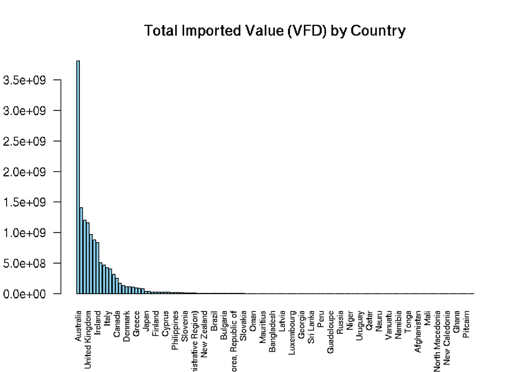

```r
# Calculate the total imported value (VFD) by country
total_vfd_by_country <- aggregate(VFD ~ Country, data = meds, sum)

# Sort the data in descending order based on total VFD
total_vfd_by_country <- total_vfd_by_country[order(-total_vfd_by_country$VFD), ]

# Create a bar plot
barplot(total_vfd_by_country$VFD, names.arg = total_vfd_by_country$Country, las = 2, cex.names = 0.7, col = "skyblue", main = "Total Imported Value (VFD) by Country")
```

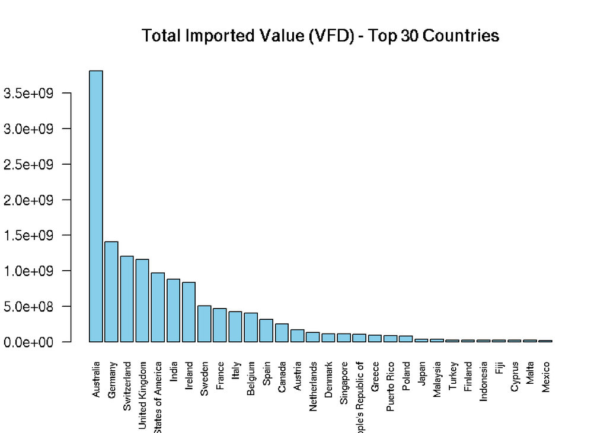

```r
# Set the number of top countries to display
top_countries <- 30

# Get the top 30 countries by volume
top_countries_data <- total_vfd_by_country[1:top_countries, ]

# Create a bar plot for the top 30 countries
barplot(top_countries_data$VFD, names.arg = top_countries_data$Country, las = 2, cex.names = 0.7, col = "skyblue", main = "Total Imported Value (VFD) - Top 30 Countries")
```